# Atividade nº 03 - Estruturas de Dados em R

Lucas Henrique Nogueira

25/05/2024

# Lista de Exercícios

## 1) Matriz:

- Dado o seguinte sistema de equações:

$$\left\{
\begin{aligned}
x + 2y + 3z &=& 20 \\
2x + 5y + 9z &=& 100 \\
5x + 7y + 8z &=& 200
\end{aligned}
\right.$$

- Reescrevendo na forma de resolução matricial:

$$\begin{aligned}
\text{Ax = B} \implies
\end{aligned}
\begin{pmatrix}
1 & 2 & 3 \\
2 & 5 & 9 \\
5 & 7 & 8
\end{pmatrix}
\begin{pmatrix}
x \\
y \\
z
\end{pmatrix}
=
\begin{pmatrix}
20 \\
100 \\
200
\end{pmatrix}$$

```r
A <- matrix(c(1, 2, 3, 2, 5, 9, 5, 7, 8), nrow = 3, byrow = T)
B <- c(20, 100, 200)
```

- Foi constatado pelo cálculo do determinante que o sistema possui uma única solução:

$$\det(A) = 2 > 0 \implies \text{Solução única}$$

```r
det.A <- det(A)
det.A
```

```
## [1] 2
```

- Por fim a solução foi determinada:

$$S = \left\{
\begin{aligned}
x &= 320 \\
y &= -360 \\
z &= 140
\end{aligned}
\right.$$

```r
if(det.A != 0){
  sol <- solve(A, B)
  sol
} else {
  print("O Sistema não possui solução")
}
```

```
## [1]  320 -360  140
```

## 2) Fatores:

- 1. Troca de níveis de um vetor de fatores:
  - Dado um vetor de fatores:

  $$\text{z <- factor(c("p", "q", "p",
  "r", "q"))}$$

  ```r
  z <- factor(c("p", "q", "p", "r", "q"))
  z
  ```

  ```
  ## [1] p q p r q
  ## Levels: p q r
  ```

  - Trocando o nível “p” por “w”

  ```r
  levels(z)[levels(z) == "p"] <- "w"
  z
  ```

  ```
  ## [1] w q w r q
  ## Levels: w q r
  ```

- 2. Concatenação de dois vetores de fatores e funcionamento do comando `sample()` com a semente 666:
     $$\left\{
     \begin{aligned}
     s1 \ \text{<- factor(sample(letters, size=5, replace=TRUE))}\qquad
     \text (1)\\
     s2 \ \text{<- factor(sample(letters, size=5, replace=TRUE))}\qquad
     \text (2)
     \end{aligned}
     \right.$$
  - Gerando números aleatórios com o comando `sample()`:

  ```r
  set.seed(666)
  sample(1:10, replace = T)
  ```

  ```
  ##  [1] 5 9 1 2 3 5 3 6 8 7
  ```

  - Criando os vetores S1 e S2 e concatenando-os

  ```r
  s1 <- factor(sample(letters, size = 5, replace = TRUE))
  s1
  ```

  ```
  ## [1] r q z p f
  ## Levels: f p q r z
  ```

  ```r
  s2 <- factor(sample(letters, size = 5, replace = TRUE))
  s2
  ```

  ```
  ## [1] o x i d k
  ## Levels: d i k o x
  ```

  ```r
  s_concatenado <- factor(c(s1, s2))
  s_concatenado
  ```

  ```
  ##  [1] r q z p f o x i d k
  ## Levels: f p q r z d i k o x
  ```

- 3. Conjunto de dados `íris` e a função `cut()` com as seguintes frequências (32, 41, 42, 24, 11):

  ```r
  data(iris)

  intervalos <- c(4.30, 5.02, 5.74, 6.46, 7.18, 7.901)
  rotulos <- c("(4.3, 5.02]", "(5.02, 5.74]", "(5.74, 6.46]",
               "(6.46, 7.18]", "(7.18, 7.9]")

  dados.categorizados <- cut(iris$Sepal.Length, breaks = intervalos,
                             labels = rotulos, right = F)
  contagem <- table(dados.categorizados)
  contagem
  ```

  ```
  ## dados.categorizados
  ##  (4.3, 5.02] (5.02, 5.74] (5.74, 6.46] (6.46, 7.18]  (7.18, 7.9]
  ##           32           41           42           24           11
  ```

- 4. Gerando uma tabela de contingência a partir do conjunto de dados `iris` com o fator `Species`:

  ```r
    categorias <- table(iris$Sepal.Length < 5, iris$Species)

    rownames(categorias) <- c("FALSE", "TRUE")
    colnames(categorias) <- levels(iris$Species)

    categorias
  ```

  ```
  ##
  ##         setosa versicolor virginica
  ##   FALSE     30         49        49
  ##   TRUE      20          1         1
  ```

- 5. Adicionando mais um nível no vetor de fator de reposta já criado:

  $$\text{respostas <- factor(c("Concordo",
  "Concordo", "Concordo fortemente",
  "Discordo", "Concordo"))}$$

  ```r
    respostas <- factor(c("Concordo", "Concordo", "Concordo fortemente",
                      "Discordo", "Concordo"))
    respostas <- factor(respostas, levels = c("Concordo fortemente",
        levels(respostas)[-which(levels(respostas) == "Concordo fortemente")]))

    levels(respostas) <- c(levels(respostas), "Discordo fortemente")
    respostas
  ```

  ```
  ## [1] Concordo            Concordo            Concordo fortemente
  ## [4] Discordo            Concordo
  ## Levels: Concordo fortemente Concordo Discordo Discordo fortemente
  ```

- 6. Encontrando os índices dos valores e combinando com os índices dos níveis do fator:

  $$\text{x <- factor(c("alto", "baixo",
  "médio", "alto", "alto",
  "baixo", "médio"))}$$

  ```r
  x <- factor(c("alto", "baixo", "médio", "alto", "alto", "baixo", "médio"))

## 3) Listas:

- 1. Dado p, q e x, qual o valor de x[2]?
     $$\left\{
     \begin{aligned}
     &\text{p <- c(2, 7, 8)} \\
     &\text{q <- c("A", "B", "C")} \\
     &\text{x <- list(p, q)}
     \end{aligned}
     \right.
     \begin{aligned}
     \qquad \text{x[2]} = \text{"A", "B", "C"}
     \end{aligned}$$

  ```r
  p <- c(2, 7, 8)
  q <- c("A", "B", "C")
  x <- list(p, q)
  x[2]
  ```

  ```
  ## [[1]]
  ## [1] "A" "B" "C"
  ```

- 2. Dado w, v e x, qual comando substituirá “A” em x por “K”?
     $$\left\{
     \begin{aligned}
     &\text{w <- c(2, 7, 8)} \\
     &\text{v <- c("A", "B", "C")} \\
     &\text{x <- list(w, v)}
     \end{aligned}
     \right.
     \begin{aligned}
     \qquad &\text{x[1]} = \text{2, 7, 8} \\
     \qquad &\text{x[2]} = \text{"K", "B",
     "C"}
     \end{aligned}$$

  ```r
  w <- c(2, 7, 8)
  v <- c("A", "B", "C")
  x <- list(w, v)
  x[[2]] <- replace(x[[2]], x[[2]] == "A", "K")
  x
  ```

  ```
  ## [[1]]
  ## [1] 2 7 8
  ##
  ## [[2]]
  ## [1] "K" "B" "C"
  ```

- 3. Dado a lista `a`, qual comando dará a soma de todos os elementos de `a`?
     $$\begin{aligned}
     &\text{a <- list("x" = 5, "y" = 10,
     "z" = 15)}
     \end{aligned}
     \begin{aligned}
     \qquad \text{soma = 30}
     \end{aligned}$$

  ```r
  a <- list("x" = 5, "y" = 10, "z" = 15)
  soma <- sum(unlist(a))
  soma
  ```

  ```
  ## [1] 30
  ```

- 4. Dado a lista `nova`, qual o comando irá adicionar `1` a cada elemento do primeiro vetor de `nova`?
     $$\begin{aligned}
     \textnormal{nova <- list(a = 1:10, b = "Férias", c =
     "Olá")}
     \end{aligned}
     \begin{aligned}
     \qquad \implies \qquad \textnormal{nova\$a = 2 3 4 5 6 7 8 9 10 11}
     \end{aligned}$$

  ```r
  nova <- list(a = 1:10, b = "Férias", c = "Olá")
  nova$a <- nova$a + 1
  nova
  ```

  ```
  ## $a
  ##  [1]  2  3  4  5  6  7  8  9 10 11
  ##
  ## $b
  ## [1] "Férias"
  ##
  ## $c
  ## [1] "Olá"
  ```

- 5. Dado a lista `b`, qual o comando irá imprimir todos os elementos de `b` exceto o segundo elemento do primeiro vetor de `b`?
     $$\begin{aligned}
     \textnormal{b <- list(a = 1:10, c = "Olá", d =
     "AA")}
     \end{aligned}
     \begin{aligned}
     \qquad \implies \qquad \textnormal{b\$a = 1 3 4 5 6 7 8 9 10}
     \end{aligned}$$

```r
  b <- list(a = 1:10, c = "Olá", d = "AA")
  b$a <- b$a[-2]
  b
```

```
## $a
## [1]  1  3  4  5  6  7  8  9 10
##
## $c
## [1] "Olá"
##
## $d
## [1] "AA"
```

- 6. Dado a lista `x`, qual o comando irá acrescentar um novo item `z` à lista `x` com z = “Novo item”?
     $$\begin{aligned}
     \textnormal{x <- list(a = 5:10, c = "Olá", d =
     "AA")}
     \end{aligned}
     \begin{aligned}
     \qquad \implies \qquad \textnormal{x\$z = "Novo item"}
     \end{aligned}$$

```r
  x <- list(a = 5:10, c = "Olá", d = "AA")
  x$z <- "Novo item"
  x
```

```
## $a
## [1]  5  6  7  8  9 10
##
## $c
## [1] "Olá"
##
## $d
## [1] "AA"
##
## $z
## [1] "Novo item"
```

- 7. Dado a lista `y`, qual o comando irá atribuir os nomes (“um”, “dois”, “três”) aos três elementos de `y`?
     $$\begin{aligned}
     \textnormal{y <- list(1:10, “string”, 666)} \qquad \implies \qquad
     \end{aligned}
     \left\{
     \begin{aligned}
     &\textnormal{y\$um = 1 2 3 4 5 6 7 8 9 10} \\
     &\textnormal{y\$dois = "string"} \\
     &\textnormal{y\$três = 666}
     \end{aligned}
     \right.$$

```r
  y <- list(1:10, "string", 666)
  names(y) <- c("um", "dois", "três")
  y
```

```
## $um
##  [1]  1  2  3  4  5  6  7  8  9 10
##
## $dois
## [1] "string"
##
## $três
## [1] 666
```

- 8. Dado a lista `x`, qual o comando irá apresentar o comprimento do vetor r, de x?
     $$\begin{aligned}
     \text{x <- list(y = 1:10, t = "Olá", f = "TT", r
     = 5:20)} \qquad \implies \qquad
     \end{aligned}
     \begin{aligned}
     \text{comprimento\_r = 16}
     \end{aligned}$$

```r
  x <- list(y = 1:10, t = "Olá", f = "TT", r = 5:20)
  comprimento_r <- length(x$r)
  comprimento_r
```

```
## [1] 16
```

## 4) Criando Data frame

- Dado os data frame df.A e df.B e o vetor var3
  $$\left\{
  \begin{aligned}
  &\textnormal{df.A <- data.frame(var1 = 1:5, var2 = LETTERS[1:5])}
  \\
  &\textnormal{df.B <- data.frame(var1 = 6:10, var2 =
  LETTERS[6:10])} \\
  &\textnormal{var3 <- 11:20}
  \end{aligned}
  \right.$$
- 1. Criando o data frame df.res a partir da vinculação por linhas de `df.A` e `df.B`:

```r
  df.A <- data.frame(var1 = 1:5, var2 = LETTERS[1:5])
  df.B <- data.frame(var1 = 6:10, var2 = LETTERS[6:10])

  df.res <- rbind(df.A, df.B)
  head(df.res)
```

|  | var1 | var2 |
| --- | --- | --- |
| 1 | 1 | A |
| 2 | 2 | B |
| 3 | 3 | C |
| 4 | 4 | D |
| 5 | 5 | E |
| 6 | 6 | F |

- 2. Apresentando a classe de cada coluna:

```r
  classes <- sapply(df.res, class)
  classes
```

```
##        var1        var2
##   "integer" "character"
```

- 3. Construindo o data frame df.A2 e vinculando por linhas com `df.B`

```r
  df.A2 <- data.frame(var1 = 1:6, var2 = LETTERS[1:6])

  df.res2 <- rbind(df.A2, df.B)
  tail(df.res2)
```

|  | var1 | var2 |
| --- | --- | --- |
| 6 | 6 | F |
| 7 | 6 | F |
| 8 | 7 | G |
| 9 | 8 | H |
| 10 | 9 | I |
| 11 | 10 | J |

- 4. Adicionando o vetor var3 como uma nova variável de `df.res`

```r
  var3 <- 11:20

  df.res <- cbind(df.res, var3)
  head(df.res)
```

|  | var1 | var2 | var3 |
| --- | --- | --- | --- |
| 1 | 1 | A | 11 |
| 2 | 2 | B | 12 |
| 3 | 3 | C | 13 |
| 4 | 4 | D | 14 |
| 5 | 5 | E | 15 |
| 6 | 6 | F | 16 |

- 5. Rearranjando as colunas nesse data frame (`df.res`) para que elas fiquem na ordem: `var1`, `var3`, `var2`.

```r
  df.res <- df.res[, c("var1", "var3", "var2")]
  head(df.res)
```

|  | var1 | var3 | var2 |
| --- | --- | --- | --- |
| 1 | 1 | 11 | A |
| 2 | 2 | 12 | B |
| 3 | 3 | 13 | C |
| 4 | 4 | 14 | D |
| 5 | 5 | 15 | E |
| 6 | 6 | 16 | F |

## 5) Trabalhando com Data Frame

- Considerando o conjunto de dados `state.x77{datasets}`.
- 1. Verificando se o objeto `state.x77` é um data frame, caso contrário será transformado em um.

```r
  if(!is.data.frame(state.x77)){
  state.x77 <- as.data.frame(state.x77)
  }

  head(state.x77)
```

|  | Population | Income | Illiteracy | Life Exp | Murder | HS Grad | Frost | Area |
| --- | --- | --- | --- | --- | --- | --- | --- | --- |
| Alabama | 3615 | 3624 | 2.1 | 69.05 | 15.1 | 41.3 | 20 | 50708 |
| Alaska | 365 | 6315 | 1.5 | 69.31 | 11.3 | 66.7 | 152 | 566432 |
| Arizona | 2212 | 4530 | 1.8 | 70.55 | 7.8 | 58.1 | 15 | 113417 |
| Arkansas | 2110 | 3378 | 1.9 | 70.66 | 10.1 | 39.9 | 65 | 51945 |
| California | 21198 | 5114 | 1.1 | 71.71 | 10.3 | 62.6 | 20 | 156361 |
| Colorado | 2541 | 4884 | 0.7 | 72.06 | 6.8 | 63.9 | 166 | 103766 |

- 2. Determinando quantos estados têm renda inferior a 4300.

```r
  estados <- sum(state.x77$Income < 4300)
  estados
```

```
## [1] 20
```

- 3. Determinando qual é o estado com maior renda.

```r
  indice <- which.max(state.x77$Income)
  estado_maior_renda <- rownames(state.x77)[indice]
  estado_maior_renda
```

```
## [1] "Alaska"
```

- 4. Construindo data frame `state`.

```r
  state_abb <- state.abb
  state_area <- state.area
  state_division <- state.division
  state_name <- state.name
  state_region <- state.region

  state <- data.frame(Abb = state_abb, Area = state_area, Division = state_division,
                      Name = state_name, Region = state_region, row.names = state_name)

  head(state)
```

|  | Abb | Area | Division | Name | Region |
| --- | --- | --- | --- | --- | --- |
| Alabama | AL | 51609 | East South Central | Alabama | South |
| Alaska | AK | 589757 | Pacific | Alaska | West |
| Arizona | AZ | 113909 | Mountain | Arizona | West |
| Arkansas | AR | 53104 | West South Central | Arkansas | South |
| California | CA | 158693 | Pacific | California | West |
| Colorado | CO | 104247 | Mountain | Colorado | West |

- 5. Construindo o data frame `estados`.

```r
  state.x77 <- state.x77[order(rownames(state.x77)), ]

  state <- state[order(rownames(state)), ]

  estados <- cbind(state, state.x77)
  head(estados)
```

|  | Abb | Area | Division | Name | Region | Population | Income | Illiteracy | Life Exp | Murder | HS Grad | Frost | Area |
| --- | --- | --- | --- | --- | --- | --- | --- | --- | --- | --- | --- | --- | --- |
| Alabama | AL | 51609 | East South Central | Alabama | South | 3615 | 3624 | 2.1 | 69.05 | 15.1 | 41.3 | 20 | 50708 |
| Alaska | AK | 589757 | Pacific | Alaska | West | 365 | 6315 | 1.5 | 69.31 | 11.3 | 66.7 | 152 | 566432 |
| Arizona | AZ | 113909 | Mountain | Arizona | West | 2212 | 4530 | 1.8 | 70.55 | 7.8 | 58.1 | 15 | 113417 |
| Arkansas | AR | 53104 | West South Central | Arkansas | South | 2110 | 3378 | 1.9 | 70.66 | 10.1 | 39.9 | 65 | 51945 |
| California | CA | 158693 | Pacific | California | West | 21198 | 5114 | 1.1 | 71.71 | 10.3 | 62.6 | 20 | 156361 |
| Colorado | CO | 104247 | Mountain | Colorado | West | 2541 | 4884 | 0.7 | 72.06 | 6.8 | 63.9 | 166 | 103766 |

- 6. Renomeando as variáveis.

```r
  colnames(estados) <- c("Abb", "Area", "Div", "Name", "Reg",
                       substr(names(state.x77), 1, 3))
  head(estados)
```

|  | Abb | Area | Div | Name | Reg | Pop | Inc | Ill | Lif | Mur | HS | Fro | Are |
| --- | --- | --- | --- | --- | --- | --- | --- | --- | --- | --- | --- | --- | --- |
| Alabama | AL | 51609 | East South Central | Alabama | South | 3615 | 3624 | 2.1 | 69.05 | 15.1 | 41.3 | 20 | 50708 |
| Alaska | AK | 589757 | Pacific | Alaska | West | 365 | 6315 | 1.5 | 69.31 | 11.3 | 66.7 | 152 | 566432 |
| Arizona | AZ | 113909 | Mountain | Arizona | West | 2212 | 4530 | 1.8 | 70.55 | 7.8 | 58.1 | 15 | 113417 |
| Arkansas | AR | 53104 | West South Central | Arkansas | South | 2110 | 3378 | 1.9 | 70.66 | 10.1 | 39.9 | 65 | 51945 |
| California | CA | 158693 | Pacific | California | West | 21198 | 5114 | 1.1 | 71.71 | 10.3 | 62.6 | 20 | 156361 |
| Colorado | CO | 104247 | Mountain | Colorado | West | 2541 | 4884 | 0.7 | 72.06 | 6.8 | 63.9 | 166 | 103766 |

- 7. Removendo a variável `div`.

```r
  estados <- subset(estados, select = -Div)
  head(estados)
```

|  | Abb | Area | Name | Reg | Pop | Inc | Ill | Lif | Mur | HS | Fro | Are |
| --- | --- | --- | --- | --- | --- | --- | --- | --- | --- | --- | --- | --- |
| Alabama | AL | 51609 | Alabama | South | 3615 | 3624 | 2.1 | 69.05 | 15.1 | 41.3 | 20 | 50708 |
| Alaska | AK | 589757 | Alaska | West | 365 | 6315 | 1.5 | 69.31 | 11.3 | 66.7 | 152 | 566432 |
| Arizona | AZ | 113909 | Arizona | West | 2212 | 4530 | 1.8 | 70.55 | 7.8 | 58.1 | 15 | 113417 |
| Arkansas | AR | 53104 | Arkansas | South | 2110 | 3378 | 1.9 | 70.66 | 10.1 | 39.9 | 65 | 51945 |
| California | CA | 158693 | California | West | 21198 | 5114 | 1.1 | 71.71 | 10.3 | 62.6 | 20 | 156361 |
| Colorado | CO | 104247 | Colorado | West | 2541 | 4884 | 0.7 | 72.06 | 6.8 | 63.9 | 166 | 103766 |

- 8. Construindo o subconjunto `estados.a`.

```r
  colnames(estados) <- trimws(colnames(estados)) # Tirando o espaço de HS
  estados.a <- subset(estados, select = -c(Lif, HS, Fro, Abb, Are))
  head(estados.a)
```

|  | Area | Name | Reg | Pop | Inc | Ill | Mur |
| --- | --- | --- | --- | --- | --- | --- | --- |
| Alabama | 51609 | Alabama | South | 3615 | 3624 | 2.1 | 15.1 |
| Alaska | 589757 | Alaska | West | 365 | 6315 | 1.5 | 11.3 |
| Arizona | 113909 | Arizona | West | 2212 | 4530 | 1.8 | 7.8 |
| Arkansas | 53104 | Arkansas | South | 2110 | 3378 | 1.9 | 10.1 |
| California | 158693 | California | West | 21198 | 5114 | 1.1 | 10.3 |
| Colorado | 104247 | Colorado | West | 2541 | 4884 | 0.7 | 6.8 |

- 1. Categorizando a variável `Illiteracy` e adicionando ao data frame `estados`.

```r
  intervalos <- c(0.0, 1.0, 2.0, Inf)
  estados$Illiteracy_Level <- cut(estados$Ill, breaks = intervalos,
                                 labels = c("baixo", "algum", "alto"), right = TRUE)

  estados$Illiteracy_Level <- factor(estados$Illiteracy_Level,
                  levels = c("baixo", "algum", "alto"))
  head(estados)
```

|  | Abb | Area | Name | Reg | Pop | Inc | Ill | Lif | Mur | HS | Fro | Are | Illiteracy_Level |
| --- | --- | --- | --- | --- | --- | --- | --- | --- | --- | --- | --- | --- | --- |
| Alabama | AL | 51609 | Alabama | South | 3615 | 3624 | 2.1 | 69.05 | 15.1 | 41.3 | 20 | 50708 | alto |
| Alaska | AK | 589757 | Alaska | West | 365 | 6315 | 1.5 | 69.31 | 11.3 | 66.7 | 152 | 566432 | algum |
| Arizona | AZ | 113909 | Arizona | West | 2212 | 4530 | 1.8 | 70.55 | 7.8 | 58.1 | 15 | 113417 | algum |
| Arkansas | AR | 53104 | Arkansas | South | 2110 | 3378 | 1.9 | 70.66 | 10.1 | 39.9 | 65 | 51945 | algum |
| California | CA | 158693 | California | West | 21198 | 5114 | 1.1 | 71.71 | 10.3 | 62.6 | 20 | 156361 | algum |
| Colorado | CO | 104247 | Colorado | West | 2541 | 4884 | 0.7 | 72.06 | 6.8 | 63.9 | 166 | 103766 | baixo |

- 10. Determinando o estado com maior renda na região oeste e que possui baixo analfabetismo.

```r
  estados_oeste <- subset(estados, Reg == "West" & Illiteracy_Level == "baixo")
  estado_maior_renda <- estados_oeste[which.max(estados_oeste$Inc), ]

  (nome_renda <- estado_maior_renda$Name)
```

```
## [1] "Nevada"
```

```r
  (renda_maxima <- estado_maior_renda$Inc)
```

```
## [1] 5149
```

## 6) Trabalhando com o array `Titanic{datasets}`

- 1. Determinando número total de passageiros com informações, número de sobreviventes, número de não sobreviventes e a taxa de sobrevivência global (%):

```r
  data("Titanic")

  (total_passageiros <- sum(Titanic))
```

```
## [1] 2201
```

```r
  (sobreviventes <- sum(Titanic[,,,"Yes"]))
```

```
## [1] 711
```

```r
  (nao_sobreviventes <- sum(Titanic[,,,"No"]))
```

```
## [1] 1490
```

```r
  (taxa_sobrevivencia <- sobreviventes / total_passageiros * 100)
```

```
## [1] 32.3035
```

- 2. Determinando os passageiros por sexo e por classe de bilhete:

```r
  (passageiros_genero <- apply(Titanic, c("Sex"), sum))
```

```
##   Male Female
##   1731    470
```

```r
  (passageiros_classe <- apply(Titanic, c("Class", "Sex"), sum))
```

```
##       Sex
## Class  Male Female
##   1st   180    145
##   2nd   179    106
##   3rd   510    196
##   Crew  862     23
```

- 3. Determinando taxa de sobrevivência dos passageiros por sexo:

```r
  (sobreviventes_sexo <- apply(Titanic[,,,"Yes"], "Sex", sum))
```

```
##   Male Female
##    367    344
```

```r
  (nao_sobreviventes_sexo <- apply(Titanic[,,,"No"], "Sex", sum))
```

```
##   Male Female
##   1364    126
```

```r
  (total_passageiros <- sobreviventes_sexo + nao_sobreviventes_sexo)
```

```
##   Male Female
##   1731    470
```

```r
  (taxa<- round((sobreviventes_sexo / total_passageiros) * 100, 2))
```

```
##   Male Female
##  21.20  73.19
```

- 4. Determinando a distribuição de idade por classe de bilhete, por sexo:

```r
  titanic_df <- as.data.frame(Titanic)
(distrib_idade_classe_sexo <- aggregate(Freq ~ Class + Sex + Age, data = titanic_df, sum))
```

| Class | Sex | Age | Freq |
| --- | --- | --- | --- |
| 1st | Male | Child | 5 |
| 2nd | Male | Child | 11 |
| 3rd | Male | Child | 48 |
| Crew | Male | Child | 0 |
| 1st | Female | Child | 1 |
| 2nd | Female | Child | 13 |
| 3rd | Female | Child | 31 |
| Crew | Female | Child | 0 |
| 1st | Male | Adult | 175 |
| 2nd | Male | Adult | 168 |

[output cut: 6 more lines]

- 5. Análise em relação a chance de sobrevivência de acordo com o sexo, a classe do bilhete e a idade(adulto ou criança):

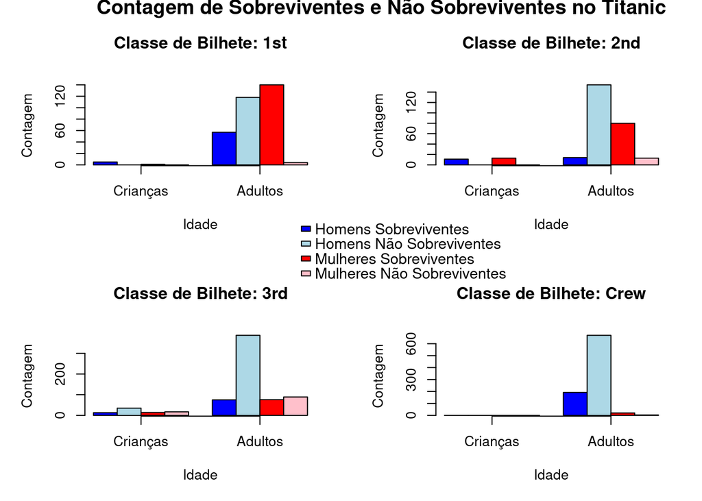

```r
distrib_idade_classe_sexo_surv <- aggregate(Freq ~ Class + Sex + Age + Survived,
                                    data = titanic_df, sum)

par(mfrow = c(2, 2), mar = c(5, 5, 5, 2) + 0.1)

classes <- unique(distrib_idade_classe_sexo_surv$Class)

for (classe in classes) {
  subset_data <- subset(distrib_idade_classe_sexo_surv, Class == classe)
  male_survived <- subset(subset_data, Sex == "Male" & Survived == "Yes")$Freq
  male_not_survived <- subset(subset_data, Sex == "Male" & Survived == "No")$Freq
  female_survived <- subset(subset_data, Sex == "Female" & Survived == "Yes")$Freq
  female_not_survived <- subset(subset_data, Sex == "Female" & Survived == "No")$Freq
  bp <- barplot(
    height = rbind(male_survived, male_not_survived, female_survived, female_not_survived),
    beside = TRUE,
    col = c("blue", "lightblue", "red", "pink"),
    main = paste("Classe de Bilhete:", classe),
    xlab = "Idade",
    ylab = "Contagem"
  )
  axis(1, at = colMeans(bp), labels = c("Crianças", "Adultos"))
}

par(mfrow = c(1, 1))
legend("center",  legend = c("Homens Sobreviventes", "Homens Não Sobreviventes",
 "Mulheres Sobreviventes", "Mulheres Não Sobreviventes"), y.intersp = 1.4, x.intersp = 0.4,
 fill = c("blue", "lightblue", "red", "pink"),bty = "n", inset = c(1, 1), cex = 0.9)
title(main = "Contagem de Sobreviventes e Não Sobreviventes no Titanic", line = 4.4)
```

A análise dos gráficos revela que três fatores principais - sexo, classe do bilhete e idade - tiveram um impacto significativo nas chances de sobrevivência dos passageiros do Titanic.

Sexo: A maioria das mulheres sobreviveu ao desastre, enquanto a maioria dos homens não. Isso é um reflexo da política de “mulheres e crianças primeiro” adotada durante a evacuação do navio.

Classe do Bilhete: Os passageiros da primeira classe tiveram a maior taxa de sobrevivência, seguidos pelos da segunda classe. Infelizmente, os passageiros da terceira classe tiveram a menor taxa de sobrevivência. Este padrão evidencia as desigualdades sociais existentes na época e o acesso diferenciado aos recursos de sobrevivência no navio.

Idade: As crianças tiveram uma taxa de sobrevivência relativamente alta, reforçando a prioridade dada a elas durante a evacuação. Entre os adultos, a taxa de sobrevivência variou, sendo em geral menor que a das crianças.

Esses resultados demonstram claramente como fatores sociais e demográficos influenciaram as chances de sobrevivência dos passageiros do Titanic.